# Лабораторная работа No4

Операционные системы

Нджову Н.

Российский университет дружбы народов, Москва, Россия

08 марта 2024

## Цель работы

Цель работы является получение навыков правильной работы с репозиториями git.

## Задание

1. Выполнить работу для тестового репозитория.
2. Преобразовать рабочий репозиторий в репозиторий с git-flow и conventional commits.

## 1. Установка git-flow

Сначала я включаю репозиторий copr(рис.1),после этого устанавливаю gitflow(рис.2)

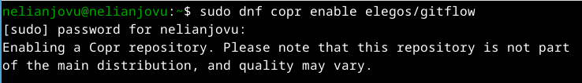

включение репозиторий copr

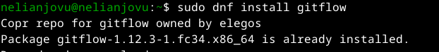

установки gitflow

## 2. Установка Node.js

Я устанавливаю nodejs.На Node.js базируется программное обеспечение для семантического версионирования и общепринятых коммитов(рис.3)

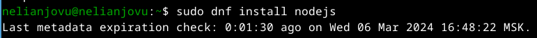

установки nodejs

## 2. Установка Node.js

Потом я устанавливаю pnpm(рис.4)

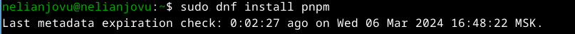

установки pnpm

## 3. Настройка Node.js

Для работы с Node.js добавим каталог с исполняемыми файлами, устанавливаемыми yarn, в переменную PATH.Я запускаю команду pnpm setup. Эта команда автоматически устанавливает yarn в переменную path(рис 5)

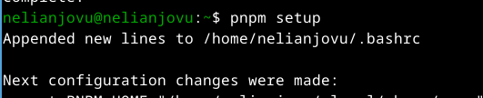

настройка node.js

Затем я выпольняю команду source ~/.bashrc

## 4. Общепринятые коммиты

Я запускаю команду, которая используется для помощи в форматировании коммитов.При этом устанавливается скрипт git-cz, который мы и будем использовать для коммитов(рис.6)

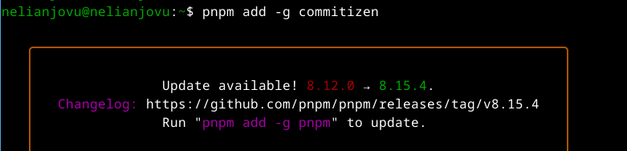

commitizen

## 4. Общепринятые коммиты

Я запускаю команду, которая испоьзуется для помощи в создании логов(рис.7)

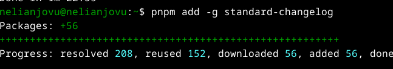

standard-changelog

## 4. Общепринятые коммиты

Я создаю новый репозиторий под названием git-extended

Я клонирую его в рабочную папку

Потом я делаю первый коммитов и выкладываю его на github(рис.8)

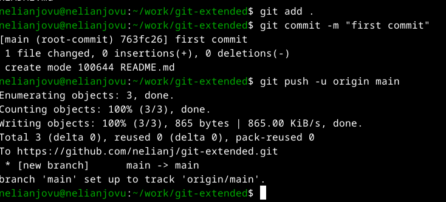

первый коммитов

## 4. Общепринятые коммиты

Я создаю файл package.json с помощью команды pnpm init.Этот файл важен, поскольку он содержит метаданные о проекте(рис.9)

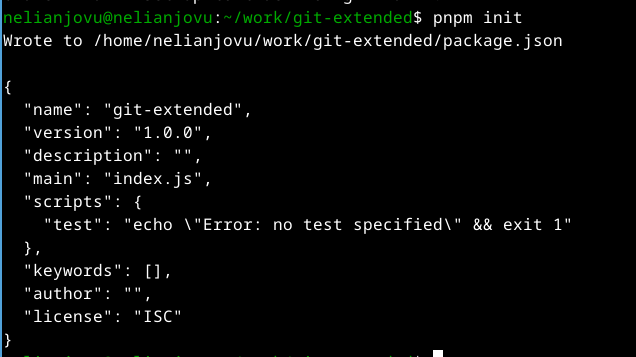

создание файла

## 4. Общепринятые коммиты

Я сконфигурирую формат коммитов. Для этого я дабавлю в файл package.json команду для формирования коммитов(рис.10)

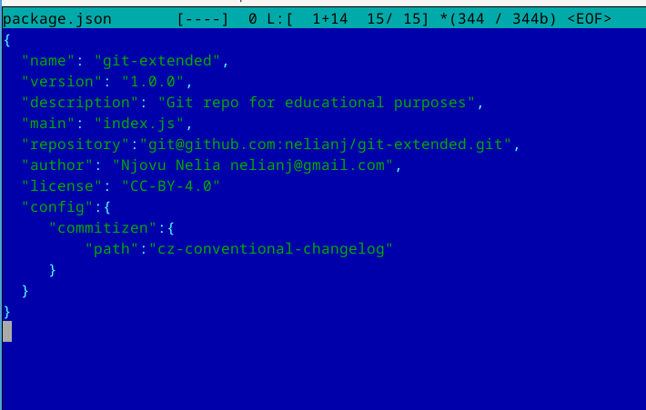

Конфигурация для пакетов Node.js

## 4. Общепринятые коммиты

Потом добавлю новый файл на github

Я выпоняю коммитов с помощью git cz(рис.11)

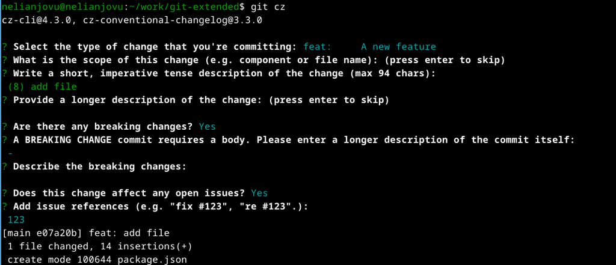

выполнение коммитов

## 4. Общепринятые коммиты

Затем я отправляю на github

Я инициализирую git flow с помощью команду git flow init(рис.12)

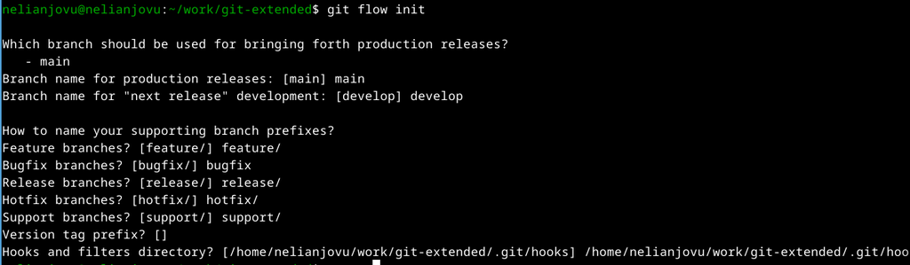

инициализирование git flow

## 4. Общепринятые коммиты

Я проверяю что я на ветке develop(рис.13)

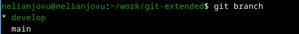

проверка если я на ветке develop

## 4. Общепринятые коммиты

Я загружаю весь репозиторий в хранилище(рис.14)

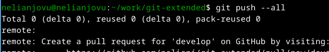

загрузка весь репозиторий

## 4. Общепринятые коммиты

Я устанавливаю внешнюю ветку как вышестоящую для этой ветки(рис.15)

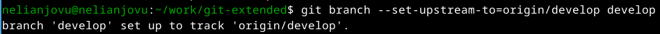

вышестоящая ветка

## 4. Общепринятые коммиты

Я создаю релиз с версиеи 1.0.0(рис.16)

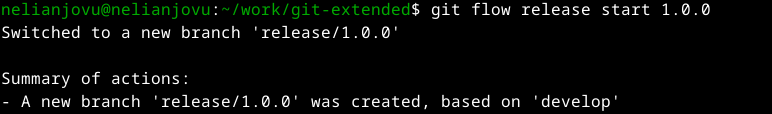

создание релиз с версиеи 1.0.0

## 4. Общепринятые коммиты

Потом я создаю журнал изменений(рис.17)

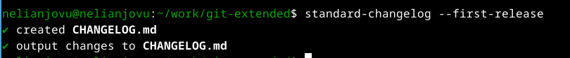

создание журнала изменений

## 4. Общепринятые коммиты

После этого я дабовлю журнал изменений в индекс(рис.18)

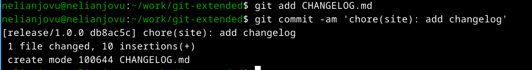

дабовление журнала изменнений в индекс

## 4. Общепринятые коммиты

Я заполняю релизную ветку в основную ветку(рис.19)

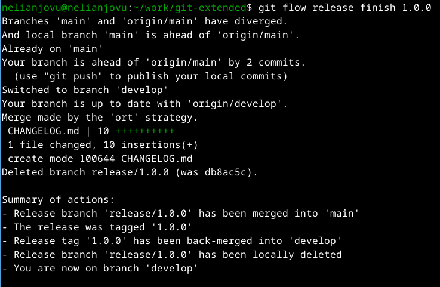

заполнения релизной ветки

## 4. Общепринятые коммиты

Я отправляю данные на github(рис.20)

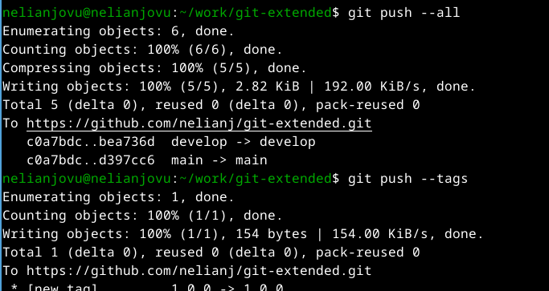

отправление на github

## 4. Общепринятые коммиты

Я создаю релиз на github(рис.21)

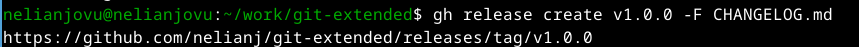

создание релиз на github

## 4. Общепринятые коммиты

Я создаю ветку для новой функциональности(рис.22)

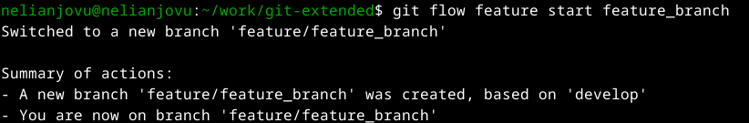

создание ветки

По окончании разработки новой функциональности следующим шагом следует объединить ветку feature_branch c develop(рис.23)

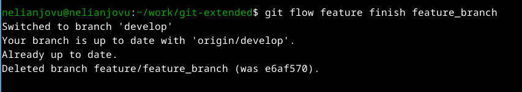

объединение ветки

## 4. Общепринятые коммиты

Я создаю релиз с версиеи 1.2.3

Я обновлю номер версии в файле package.json. Установливаю её в 1.2.3(рис.24)

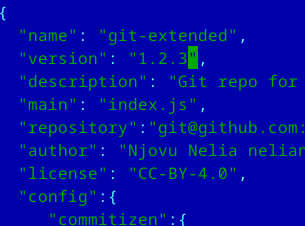

обновление номер версии

## 4. Общепринятые коммиты

Я создаю журнал изменений(рис.25)

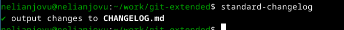

создание журнала изменений

Я добавляю журнал изменений в индекс

Заполняю релизную ветку в основную ветку

## 4. Общепринятые коммиты

Я отправяю данные на github

Я создаю релиз на github с комментарием из журнала изменений(рис.26)

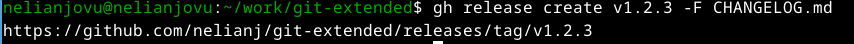

создание релиз на github

# Выводы

Выполняя эту лабораторную работу, я получаю навыки правильной работы с репозиториями git.